# Midterm Lab

STAT 359 Data Visualization

# Overview

For reference, the graphics were generated to be 6 inches by 6 inches. Tasks 1 & 2 ask you to replicate plots and provide some basic insight into what the graphics are communicating. Task 3 asks you to provide short descriptions/explanations regarding issues and concepts in `ggplot2`.

# Datasets

The `appendix.csv` file is from Kaggle.com (https://www.kaggle.com/edx/course-study/version/1).

# Tasks

0a. Describe each of the following:

1. `ggplot()`
2. `aes()`
3. `geoms`
4. `stats`
5. `scales`
6. `theme()`

0b. Explain the difference between using this code `geom_point(aes(color = VARIABLE))` as opposed to using `geom_point(color = VARIABLE)`.

1a. Run the below code and answer the below questions.

```r
library(tidyverse)

online_course_data <- read_csv('appendix.csv', na = '---') %>%
  mutate(Institution = factor(Institution),
         `Honor Code Certificates`  = factor(`Honor Code Certificates`),
         `Course Subject` = factor(`Course Subject`))

dim(online_course_data)
```

```
## [1] 290  23
```

```r
glimpse(online_course_data)
```

```
## Observations: 290
## Variables: 23
## $ Institution                                    <fct> MITx, MITx, MIT...
## $ `Course Number`                                <chr> "6.002x", "6.00...
## $ `Launch Date`                                  <chr> "09/05/2012", "...
## $ `Course Title`                                 <chr> "Circuits and E...
## $ Instructors                                    <chr> "Khurram Afridi...
## $ `Course Subject`                               <fct> Science, Techno...
## $ Year                                           <int> 1, 1, 1, 1, 1, ...
## $ `Honor Code Certificates`                      <fct> 1, 1, 1, 1, 1, ...
## $ `Participants (Course Content Accessed)`       <int> 36105, 62709, 1...
## $ `Audited (> 50% Course Content Accessed)`      <int> 5431, 8949, 285...
## $ Certified                                      <int> 3003, 5783, 208...
## $ `% Audited`                                    <dbl> 15.04, 14.27, 1...
## $ `% Certified`                                  <dbl> 8.32, 9.22, 12....
## $ `% Certified of > 50% Course Content Accessed` <dbl> 54.98, 64.05, 7...
## $ `% Played Video`                               <dbl> 83.20, 89.14, 8...
## $ `% Posted in Forum`                            <dbl> 8.17, 14.38, 14...
## $ `% Grade Higher Than Zero`                     <dbl> 28.97, 39.50, 3...
## $ `Total Course Hours (Thousands)`               <dbl> 418.94, 884.04,...
## $ `Median Hours for Certification`               <dbl> 64.45, 78.53, 6...
## $ `Median Age`                                   <dbl> 26, 28, 27, 28,...
## $ `% Male`                                       <dbl> 88.28, 83.50, 7...
## $ `% Female`                                     <dbl> 11.72, 16.50, 2...
## $ `% Bachelor's Degree or Higher`                <dbl> 60.68, 63.04, 5...
```

1b. How many courses are there per subject for each instiution?

Notes: * Change the y-label to be more descriptive than “count”

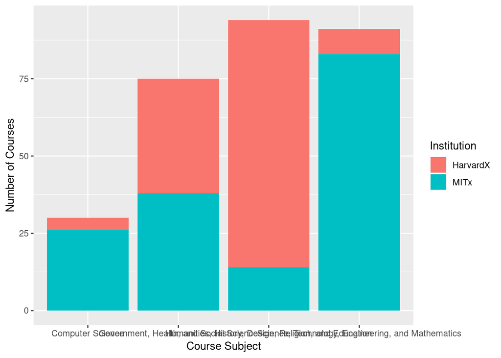

```r
ggplot(online_course_data, aes(`Course Subject`, fill = Institution)) +
  geom_bar() +
  labs(y = 'Number of Courses')
```

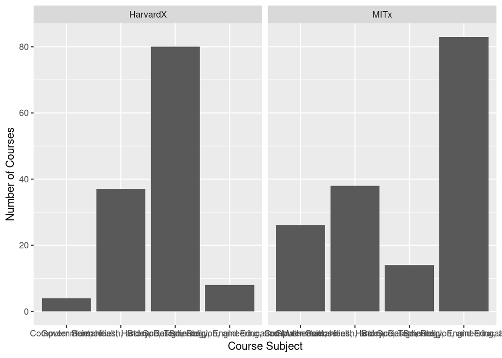

```r
# OR

ggplot(online_course_data, aes(`Course Subject`)) +
  geom_bar() +
  facet_wrap(~ Institution) +
  theme(legend.position="bottom") +
  labs(y = 'Number of Courses')
```

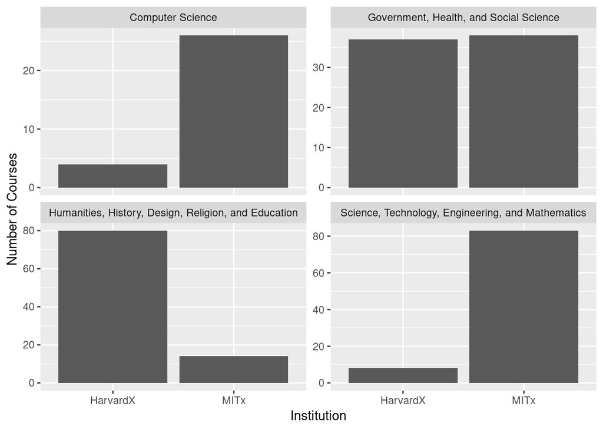

```r
# OR

ggplot(online_course_data, aes(Institution)) +
  geom_bar() +
  facet_wrap(~ `Course Subject`, scales = 'free_y') +
  theme(legend.position="bottom") +
  labs(y = 'Number of Courses')
```

1c. In one plot, show the `Median Age` of Course Subjects (including the 25th, 50th, and 75th percentiles) broken out by both Year and Institution.

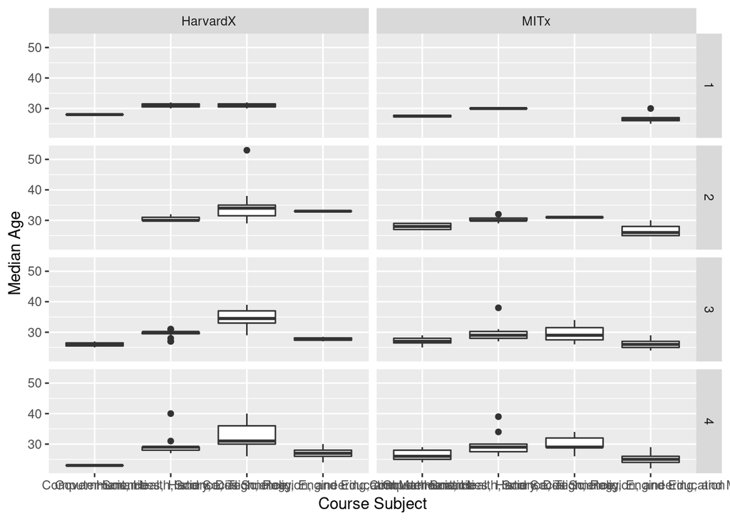

```r
ggplot(online_course_data, aes(`Course Subject`, `Median Age`)) +
  geom_boxplot() +
  facet_grid(Year ~ Institution)
```

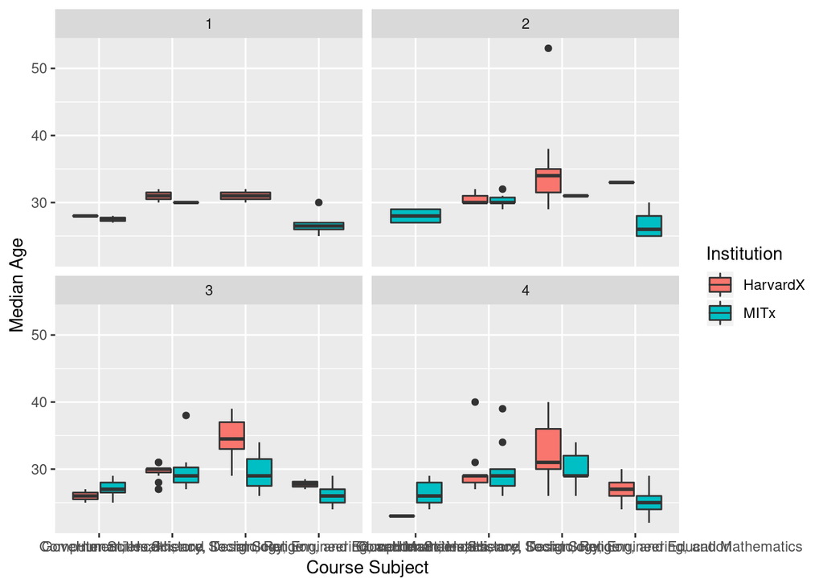

```r
# OR

ggplot(online_course_data, aes(`Course Subject`, `Median Age`, fill = Institution)) +
  geom_boxplot() +
  facet_wrap(~ Year)
```

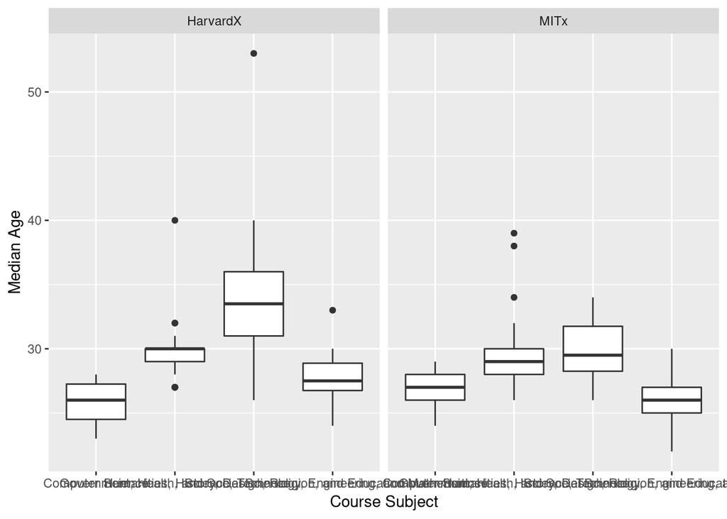

```r
# OR

ggplot(online_course_data, aes(`Course Subject`, `Median Age`, fill = Year)) +
  geom_boxplot() +
  facet_wrap(~ Institution)
```

2d. Recreate the below visualization.

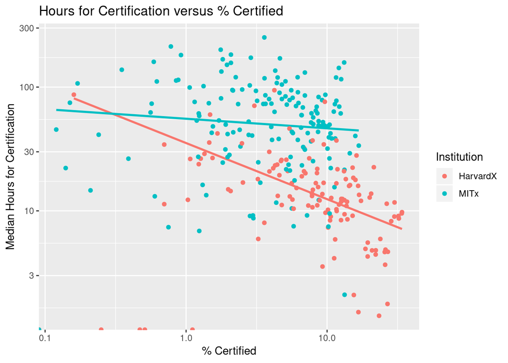

```r
ggplot(online_course_data, aes(`% Certified`, `Median Hours for Certification`, color = Institution)) +
  geom_smooth(se = FALSE, method = 'lm', show.legend = FALSE) +
  geom_point() +
  scale_y_log10() +
  scale_x_log10() +
  labs(title = 'Hours for Certification versus % Certified')
```

2e. Create a visualization which plots `Audited (> 50% Course Content Accessed)` against `% Bachelor's Degree or Higher` and displays the name of the course instead of a dot, broken out by the course subject.

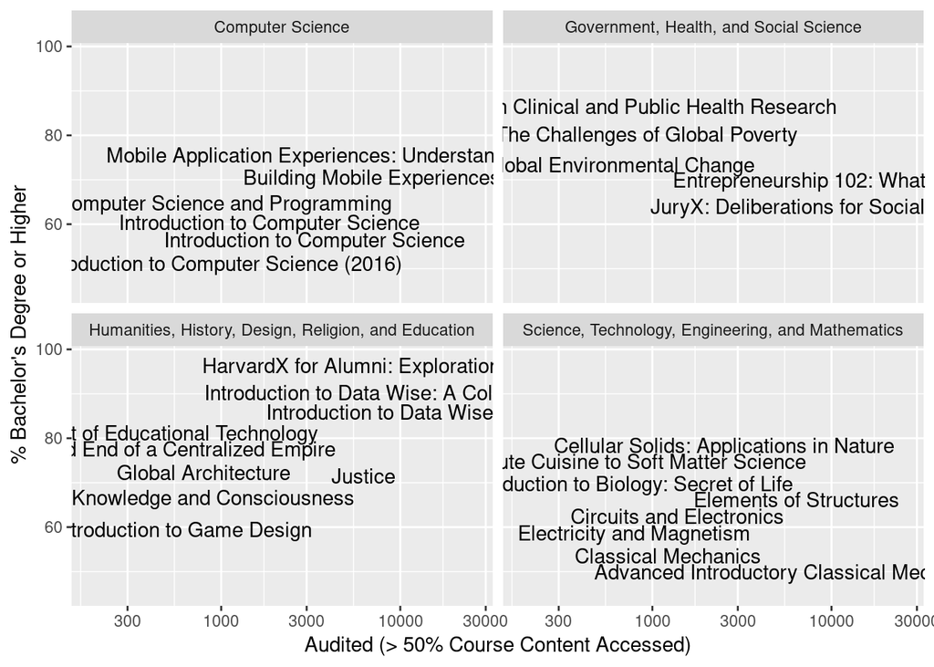

```r
ggplot(online_course_data, aes(`Audited (> 50% Course Content Accessed)`, `% Bachelor's Degree or Higher`, label = `Course Title`)) +
  geom_text(check_overlap = TRUE, vjust = 'inward', hjust = 'inward') +
  scale_x_log10() +
  facet_wrap(~ `Course Subject`)
```